# Death causes

Humanity’s ability to prevent death has improved tremendously in the last 150 years. Not only can we save many more sick and injured people but we also know more about preventing illness and accidents. For example, it is well known that both drinking and smoking increase the risk of an early death while eating vegetables and wearing seatbelts, likewise, decrease the risk. It is great that people know what is good and what is bad for their health, however there is a lot more to learn. How much does the bad habits increase one’s risk of death? And what types of illness and tragedies are related to each habit? On this website you can based on your specific circumstances and habits, get an estimated age of death and a breakdown of how responsible each disease or habit is for your death. These numbers are computed by our mathematical model based on results from a compiled list of scientific papers.

#### Motivating example

Imagine a world where we kept track of cause of death but there was no research in their underlying causes. Furthermore, imagine that you were an old person living in a nice house in a quiet suburb and you asked the scientists to come up with an estimate of your risk of dying from homicide. Naturally, one would think that you would have less risk of dying from homicide than, say, a drug dealer. However, the scientists would not have any information about such tendencies as there is no research about the underlying cause in this hypothetical world. Therefore, their best estimate would be the crude rate; for example, in America the murder rate is 5.0 out of 100,000 per year, so the scientist would tell everyone that their chance of dying from homicide was 5/100,000=0.005% each year. Now, imagine that the scientists decided to actually do some research in the subject; they examined how many people who were murdered in their house had a gun, and compared it to how many people who weren’t murdered, had guns in their house. They might find that the gun-owners had approximately 1.9 times higher risk of death from homicide in their home than non-owners (as found by the researchers Dahlberg, Ikeda, and Kresnow (2004)). If our hypothetical world had a gun ownership rate of 40% of households and 50% of homicides occurring in the home (like America has today), the scientists could then give 3 different answers to the question about your risk of dying from homicide:

- If they know that your household has a gun, each year the risk of you dying from homicide is $0.00599\%$.
- If they know that your household doesn’t have a gun, each year the risk of you dying from homicide is $0.00434\%$
- If they don’t know whether your household has a gun, they have to use the default rate and say that each year your risk of dying from homicide is $0.005\%$

The formulas are explained in Including risk factors.

The mathematical model that we use works similarly. We start with a neutral model that only knows the rates of each death cause for each age. As we put more scientific results into the model, we can more accurately estimate the risks for the individual person. Finding these results is a never-ending task and a task filled with hard decisions. We have to decide which numbers to include in the model and how to combine the results. For example, what happens to your risk of homicide if you are both a drug addict and has a gun in your home? We deal with this case by case and describe our considerations in the section Risk Factor Choices.

# The mathematical model

### The neutral model

When a user haven’t filled out any personal data, the program will use the *neutral* model. For every deadly illness and accident type, the neutral model knows what proportion of the American population dies in each 5-year age bracket every year. This data comes from the [Underlying Cause of Death data set on the CDC website](https://wonder.cdc.gov/). The illnesses and accidents are split into ICD10 codes, which is a standardized system used by doctors to classify cause of death. There are thousands of different ICD codes so we group them into sensible categories that we call *death causes*. Using this data we can compute the probability of dying from each death cause and expected age of death. In the neutral model those numbers will describe the average American, but as the user inputs more and more data, the results will be more personal. How personal it can become depends on the size and quality of our collection of risk factors and as we add more risk factors, the fact that the neutral model is American means less and less.

**Formulas**

For completeness, the formula that we use to compute the probability of dying from a death cause is
$$P(\text{die from }d)=\sum_{a=0}^{119} P(d|a) \prod_{b=0}^{a-1} \Bigl(1-\sum_{d\in D}^b P(d|a) \Bigr)$$
where $P(d|a)$ is the probability of dying from the death cause $d$ between your $a$’th and $a+1$’th birthday. By $D$ we denote the set of all death causes. The sum goes to 119, because there is very little chance of living past 120 [skal vi tilføje det mere eksplicit? At vi regner frem til 120 som et slags teoretisk maksimum]. In the neutral model we use the proportions from the CDC as the $P(d|a)$ numbers, but when we start including risk factors we scale them using risk ratios or similar.

### Including risk factors

In order to compute personalized probabilities, we use *risk factors* which are different behaviors or circumstances that influence the probability of dying.

When the scientists in our hypothetical example computed the risk of dying from homicide, they used the following formula that we will unpack.
$$0.005\%\cdot 50\%+50\% \cdot 0.005\%\cdot \frac{1.9}{1.9\cdot 40 \%+1.0\cdot 60\%}$$
The first part $0.005\%\cdot 50\%$ is the risk of dying of homicide outside of your your home. For those $50\%$ of homicides we knew nothing about their underlying causes so we simply use their base rate of $0.005\%$. This means that we have effectively split up homicides into two sub death causes - homicides in your home with yearly rate $0.005\%\cdot 50\%=0.0025\%$ and homicides elsewhere with yearly rate $0.0025\%$. In this example the rates ($0.005\%$, $0.0025\%$) are the combined rate of Americans of all ages but in the actual model we use the rates specific to a certain age.

### Normalization factor

Looking at the more complicated part of the above equation, we are left with
$$0.0025\%\cdot \frac{1.9}{1.9\cdot 40 \%+1.0\cdot 60\%}$$

**Derivation**

Let us look at where it comes from. We know that the overall risk for homicides in the home is $0.0025\%$ and we know that the group that has a gun in their house should have 1.9 times higher risk of being murdered. This means that if the risk in the non-owner group is $x$, the risk of the gun-owner group is $x\cdot 1.9$. The question is now what $x$ is. To find $x$ we use that the overall risk is $0.0025\%$. Some of these $0.0025\%$ must come from the gun owner group. If we use the fact that $40\%$ of the population owns a gun, they would contribute with $x\cdot 1.9\cdot 40\%$ of the $0.0025\%$ and likewise the non-owners will contribute with $x\cdot1.0\cdot60\%$. In total we get an equation where we can isolate $x$.

$$x\cdot 1.0 \cdot 60\%+x\cdot 1.9\cdot 40\%=0.0025\%$$
$$x \cdot (60\%+ 1.9\cdot 40\%)=0.0025\%$$
$$x=0.0025\%\frac{1}{1.0\cdot 60\%+ 1.9\cdot 40\%}$$

This last equation is the formula for the risk of dying from homicide in the home for non-owners. The risk in the gun-owning group is then
$$x\cdot 1.9=0.0025\%\frac{1.9}{1.0\cdot 60\%+ 1.9\cdot 40\%}$$
We have hereby shown the formulas.

### Smoothing

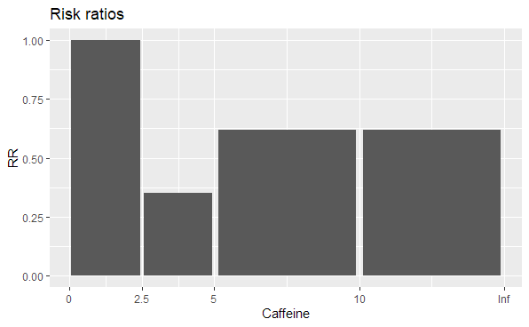

According to these numbers an average coffee consumption of 2.49 cups of coffees per day is more than twice as dangerous as drinking 2.51 cups of coffee per day. This is not realistic and only a result of the chosen binning. To get a more realistic and intuitive model, we fit a curve to binned categories.

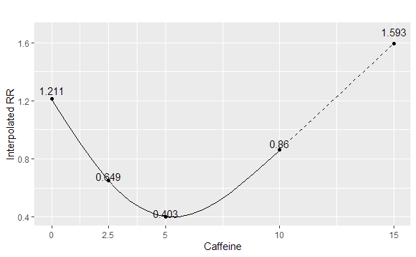

**Technical details**

We fit the curve by finding the natural cubic splines $\{N_i\}_{i=1, \dots, n}$ that minimizes the expression
$$\sum_{f} \frac{1}{\sigma_f^2}\biggl(RR(f)-\frac{1}{|f|}\int_f\sum_{i=1}^n N_i(X) \text{ d}X\biggr)^2+\lambda\int_f \Bigl|\sum_{i=1}^n N_i''(X)\Bigr|^2 \text{ d}X$$
where $f$ is a binned category, $|f|$ is the size of the bin and $\lambda$ is a tuning parameter and $\sigma_f$ is the standard deviation of the risk ratio $RR(f)$. The outer sum goes through only the finite bins and the natural cubic splines have knots around every finite bin. The tuning parameter $\lambda$ is chosen manually based on visual inspection of the fitted curve.

For the $\sigma_f$-values we should remember that the estimated spline function will be multiplied with the inverse normalization factor in the program. This means that we are really making this fit for the normalized risk ratios and so we should set $\sigma_f$ equal to *their* standard deviations. They are unfortunately not easily computed and since we adjust the tuning parameter manually anyway, we mostly set $\sigma_f=1$. One exception is that many risk ratio tables have a *base category* which are used to compare against all other categories. This base category has, by construction, risk ratio 1 with standard deviation 0. In these cases we often constrain the spline to take that value (by using Lagrange multiplier method on the above expression). However, the *normalized* risk ratio of the base category does not have standard deviation 0, so the constraint does not make the computation more correct. We do it to make the resemblance between the interpolated curve and the risk ratio histogram more clear to humans.

When the input risk ratios are arranged in a multidimensional grid, we use cross products of one-dimensional splines. The basis is
$$\{D_k(X_i)D_l(X_j)\}_{(i,j,k,l)\in I}\cup \{D_k(X_i)\}_{(k,i)\in J}$$
where $D_k(X_i)$ is the $k$’th spline base function of the $i$’th variable. The index set $I$ includes all combinations such that $i\neq j$ and $J$ is all combinations. Let $\mathcal{N}(X)$ be the spline of the multidimensional input $X=(X_1, \dots, X_m)$. The penalization term is then
$$\lambda \int_f \sum_{i=1}^m\sum_{j=1}^m\biggl|\frac{\partial}{\partial X_i \partial X_j}\mathcal N(X)\biggr|^2 \text{ d}X$$

The loss function term is the same as the in the one-dimensional case except the integral is also multidimensional.

### Interactions between risk factors

Often there are much more than one risk factor for a specific death cause. An example could be that both gun ownership and living in a violent household increase your risk of dying from a homicide in the home. The question is now, what happens if one does both? In other words, what is the *interaction* between household violence and gun ownership?

**Homicide and physical violence in the home**

The researchers Kellermann et al. (1993) found that the odds of dying from homicide was $4.4$ times higher if there had ever been a fight where someone was physically hurt in the home. In the same process they found that $5.7\%$ of their controls had ever had such a violent fight. If we say that number represents the American population, we can compute the normalization factor as $1.19=5.7\%\cdot 4.4 + 94.3\%\cdot 1$, which we can use to compute the following

- If you live in a home where someone has been physically hurt in a fight, the risk of dying from homicide in the home is $0.0025\%\cdot\frac{4.4}{1.19}=$ **0.00924%** (per year)
- If you live in a home where no one has been physically hurt in a fight, the risk of dying from homicide in the home is $0.0025\%\cdot\frac{1.0}{1.19}=$ **0.00210%** (per year)
- If you don’t consider physical violence in your home, the best guess of your risk of dying from homicide in the home is the default **0.0025%** (per year)

#### Combining physical violence and guns.

In the motivating example we talked about the research from Dahlberg, Ikeda, and Kresnow (2004) who found that a gun in one’s home makes one 1.9 times more likely to be killed in the home. Other research papers have examined the same issue and they were combined in a meta analysis by Anglemyer, Horvath, and Rutherford (2014), where they estimated the risk ratio to be 2.0 - rather than 1.9. Since much more data has been used to estimate the meta analysis estimate, we will use it from now on.

We want to combine the risk ratio for gun ownership with the results of Kellermann et al. (1993), who found that a history of domestic physical fights increases the risk of dying from homicide in the home by a factor of 4.4. If one does both, we would want our model to say that the risk is even higher than either, but how much exactly? In this example, and in many others, we have decided that we multiply the risk ratios. That is

- If you both live in a household with physical violent fights and gun(s), your risk of dying from homicide in the home is $2.0\cdot 4.4=8.8$ times higher than if you did neither.
- If there is only physical violent fights but no guns, your risk is $4.4$ times higher than if you did neither.
- If there is only guns but no physical violence, your risk is $2.0$ times higher than if you did neither.

We justify this choice by how the odds ratios were computed in the original papers. In Kellermann et al. (1993) they computed the odds ratio $4.4$ using a method that *adjusted for gun ownership*. They assumed that odds ratios for gun ownership, physical violence, race etc. should be multiplied together and then they estimated all odds ratios at once. Consequently, $4.4$ is the most correct odds ratio when multiplied together with the gun ownership odds ratio (and all the other odds ratios in their model). That is good, because that is how we use it!

However, the odds ratio 2.0 from (Anglemyer, Horvath, and Rutherford 2014) was computed from other papers where only some adjusted for physical violence. That should ideally be all the papers now that we multiply the two odds ratios. Fortunately, it doesn’t seem to matter that much;

- In Kellermann et al. (1993) they estimated the odds ratio for gun ownership adjusted for physical violence to be 2.6, which is quite near the meta analysis estimate 2.0.
- By combining the studies, the authors Anglemyer, Horvath, and Rutherford (2014) implicitly assumes that odds ratios adjusted for physical violence are statistically the same as those that are not adjust. They didn’t report any considerations or checks on this assumption (which is not strange because it is not normal in these types of meta analysis), but we can assume that they would have made a different analysis if it had become clear to them that it would be very wrong to combine them.

In general our interactions are multiplicative. The above considerations about how estimates are adjusted repeats many times in the cause-by-cause section Risk factor choices. It is not always possible to find studies that adjust for every relevant risk factor. In these cases we will often assume that they combine multiplicatively anyway, but the behavior of the program will be more speculative.

#### Combining normalization factors

To use the combined risk or odds ratio, we have to compute a new normalizing factor. Let us continue the homicide example where we multiplied the odds ratio for gun ownership (2.0) and physical violence (4.4).

To compute the normalizing factor we need to know the proportion of Americans who belong to each combination of gun ownership and physical violence. For example we need the proportion of the American population who lives in a household where there is a gun and a history of physical violence. Recall that the proportion of households that owns a gun is $40\%$, and the proportion that has a history of violence is $5.7\%$. If gun ownership were unrelated to whether there are physical violence, we would say that gun ownership and physical violence are *independent*. This means that gun owners and non-gun owners are equally likely to have a violent household (and vice versa). Then we could simply compute the joint proportion as $40\%\cdot 5.7\%=2.3\%$. It doesn’t sound outrageous that gun ownership and physical violence in the home should be independent and since we are unlikely to find the actual joint proportions, we assume that they are independent. Then the normalizing factor is
$$4.4\cdot 2.0 \cdot 40\% \cdot 5.7\%+4.4\cdot 1.0 \cdot 60\% \cdot 5.7\%+1.0\cdot 2.0 \cdot 40\% \cdot 94.3\% \\+ 1.0\cdot 1.0\cdot 60\%\cdot 94.3\%\approx 1.67$$
Notice that we could have also gotten $1.67$ by multiplying the two normalization factors of physical violence and gun ownership. That is $1.67=1.19\cdot (60\%+40\%\cdot 2)$.

We do not always assume independence between risk factors, but it will be handled on a case-by-case basis described in Risk factor choices. In many cases the independence assumption will not matter that much (see “Consequences of assuming incorrect independence” below).

**Consequences of assuming incorrect independence**

The potential caveat to assuming that they are independent is that we get a more imprecise estimate of the normalizing factor. On one hand the normalizing factor and in particular, the normalized risk are already uncertain estimates. Considering the homicide example, the normalizing factor when assuming independence was $1.67$. If we don’t assume independence but still assume that $5.7\%$ of homes have experienced physical violence and $40\%$ have guns, the lowest possible normalization factor would occur if there were no overlap between the two categories. That is,

$$4.4\cdot 2.0\cdot 0\%+4.4\cdot 1.0 \cdot 5.7\%+1.0\cdot 2.0\cdot 40\%+1.0\cdot 1.0\cdot 54.3\%=1.59.$$
The highest possible normalization factor would happen if there were complete overlap between the two. That is,

$$4.4\cdot 2.0\cdot 5.7\%+4.4\cdot 1.0 \cdot 0\%+1.0\cdot 2.0\cdot 34.3\%+1.0\cdot 1.0\cdot 60\%=1.78.$$

This means that the normalization factor will always be in the interval (1.59,1.78). For comparison the confidence interval of the 4.4-odds ratio of physical violence is $(2.2,8.8)$ (Kellermann et al. 1993) and the confidence interval of the 2.0-odds ratio of gun ownership is $(1.56,3.02)$ (Anglemyer, Horvath, and Rutherford 2014). The error from incorrectly assuming independence is therefore not the biggest source of error in this case. In general the independence assumption will matter less when the risk factors are rare or when the risk ratios are similar.

#Even though the error on the normalized risk may not be important when we don’t have the correct joint proportions, we lose a pleasant property. Correct proportions would ensure that if all Americans filled out the program and we averaged all their results, we would get the neutral model. In other words, the program would be correct on average. The uncertainty in the odds and risk ratios would still lead to overestimation of, say, some people’s risk of dying from homicide, but with the correct joint proportions some other people’s homicide risk would be correspondingly underestimated. [jeg er ikke sikker på hvorfor det er en behagelig egenskab?]

### Decompositions

This section will not be written before the method is tested.

### Interpretation

When the program says that one has a certain probability of dying of a certain cause it is under the assumption that the mathematical model is correct. If, for example, the program reports a $10\%$ probability of dying from Alzheimer’s we suggest that it should be interpreted as

> “My probability of dying from Alzheimers is 10% given the program’s collection of risk ratios and my answers to the questions (and given that I lived in the US).”

Note two things:

1. The information that the program has about the real world comes from the collection of risk ratios. The good thing about having a collection is that we can expand it indefinitely, but in contrast to probabilities calculated from a single experiment, it is harder to understand and trust a collection. Therefore, we put a lot of effort into documenting the collection.
2. As discussed in the Neutral model section, the base numbers come from the US. Ideally, the collection of risk factors were so good that it could explain the differences between the US and where the user lives. When it doesn’t, it is good to know that the numbers come from the US. For example, we have not added any risk factors for being killed by the police (yet), so if you are a European, your risk of dying from this may not be as big as the program says.

# Risk factor choices

### Colon Cancer

There are many minor risk factors for colorectal cancers. So far we have included the following

- Drinking.
- Physical activity.
- Read meat consumption.

Other relevant risk factors not included in the model are smoking, fiber intake, family history of this cancer, other cancers and obesity.

#### Interactions

We assume that the interaction between all factors in colorectal cancer is multiplicative. That means that we multiply the risk ratios for every factor to get the full risk ratio, $\text{RR}$.
$$\text{RR}=\text{RR}_{\text{drinking}}\cdot \text{RR}_{\text{physical activity}}\cdot \text{RR}_{\text{red meat}}$$
We also assume that the factors are independent when we compute the normalizing factor. This means that we compute the joint proportions, $P$, as
$$P=P_{\text{drinking}}\cdot P_{\text{physical activity}}\cdot P_{\text{red meat}}$$
There is evidence that people who drink are more physically active than those who don’t (Piazza-Gardner and Barry 2012), but that effect is negligible in our context.

#### Colorectal cancer: Drinking

We use the meta analysis of cohort studies by Cho et al. (2004). They computed a joint risk ratio that were adjusted for many other factors, including physical activity and red meat consumed. This study is also ideal because it is a big meta analysis with data divided into many bins. They found that it was slightly better to drink a little($\text{RR}=0.94$) rather than nothing($\text{RR}=1.0$), but they thought it was an artifact of many former heavy drinkers who turned to abstinence. We therefore raise the risk ratio of the light drinkers to 1.0 as well.

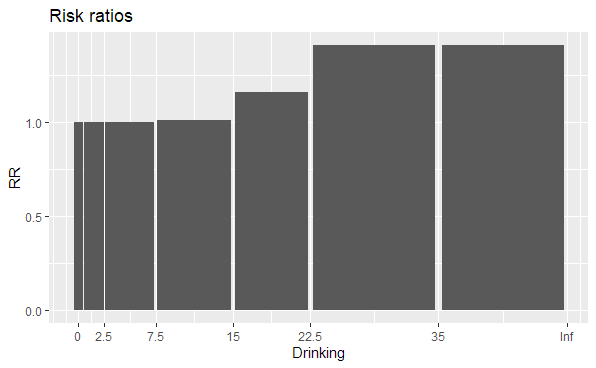

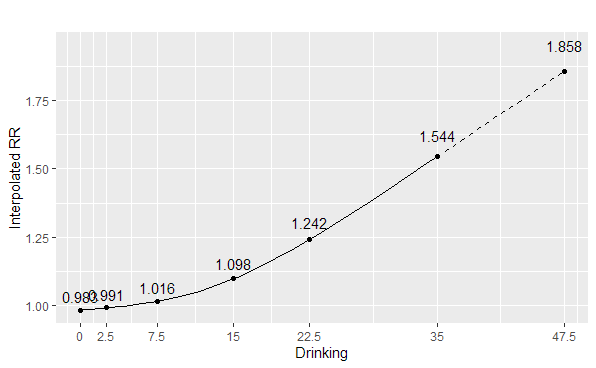

#### Colorectal cancer: Physical Activity

It seems that both physical activity at work and in the spare time matters to prevent colorectal cancer and are similar (Samad et al. 2005). We therefore obtain the risk ratios from Kyu et al. (2016), where they estimated a dose-response relationship based on total physical activity in a meta analysis. They did include studies which did not adjust for drinking and red meat consumption, but it should not be a big source of error since the factors are not causally connected (like for example BMI and physical activity would be).

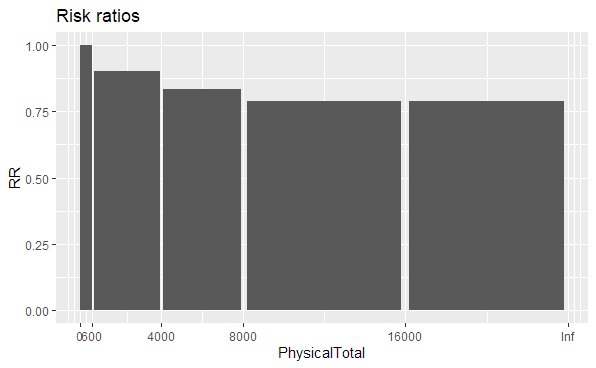

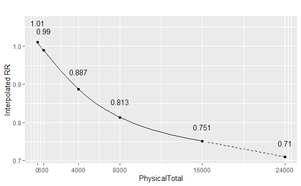

#### Colorectal cancer: Red Meat Consumption

Red meat is meat from pigs, cows, sheep or animals with similarly colored meat. Consequently, chicken is for example not classified as red meat. We use the risk ratios from Schwingshackl et al. (2018), which is a big dose-response meta analysis. Not all, but most of the big included studies in the meta analysis adjusted for physical activity and alcohol consumption, so it is very reasonable to use it in combination with our other risk factors

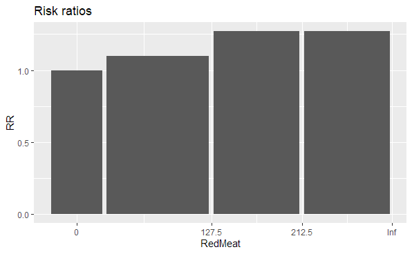

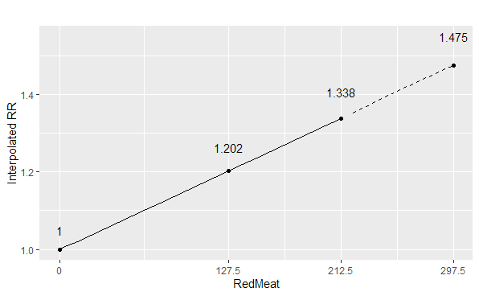

# Glossary

### Dose-response

A dose-response is a special type of analysis that are often made when considering just one risk factor that can be infinitely many different numbers. This numeric risk factor is the dose. For example, the dose could be the number of alcohol drinks per week, because it can be 0, 10, 3.4,0.02, etc. The response is most often risk ratio, odds ratio or similar. The dose-response relationship is often presented using binned dose-intervals like the example we saw in section Smoothing.

### Independence

Variables are independent, when there is absolutely no relation between them. This is equivalent to saying that if you know one (or some) of the variables, you are not any wiser about the other variables. One example is two consecutive die rolls. The result of the first die roll, doesn’t tell you anything about the result of the second, so they are independent. Risk factors, on the other hand, are rarely completely independent. Consider for example sex and eye color. At first they may seem independent, but remember that

- The proportions of different eye colors changes from country to country.
- The ratio between males and females also depends on the country

Imagine that we draw a random person in the world and we only know that he or she has brown eyes. With this tiny bit of information, we know that the person is more likely to come from a country with many brown-eyed people, and because the countries with many brown-eyed people generally have more males than females, we should now think there is a higher change that the person is male. This means that the person’s eye color affected our expectation of their sex, and so eye color and sex is not independent. It didn’t change our expectation by a lot, so we would say that they are almost independent.

The benefit of independent variables is that it makes computations easier and faster. We will therefore assume risk factors are independent when it is not too wrong (see considerations in Section Combining normalization factors).

### Meta analysis

In health research the same risk ratios, odds ratios or similar are often estimated in many different studies that varies by location and methods. The meta analysis finds these studies, removes those with unwanted methodology, and takes a kind of average of all the estimates. This averaged estimate will normally have a smaller error than any of the original estimates. A downside is that is much harder to determine the methodology behind the averaged estimate, because it will be some combination of methodology of all the included studies.

### Odds ratio

An odds ratio is two odds divided by each other. In this document, an odds is a probability divided by the complementary probability. That is, if the probability is $p=0.2=20\%$, the odds is
$$\frac{p}{1-p}=\frac{0.2}{1-0.2}=\frac{1}{4}=25\%$$

An odds ratio is then
$$OR=\frac{\frac{p_1}{1-p_1}}{\frac{p_2}{1-p_2}}$$

We will almost consequently make the approximation
$$OR=\frac{\frac{p_1}{1-p_1}}{\frac{p_2}{1-p_2}}\approx \frac{p_1}{p_2}=RR$$
which is justified when $p_1$ and $p_2$ are small or close to each other. The RR is notation for Risk Ratio

### Probability

See Risk.

### Risk

Risk is the same as probability. It represents the certainty of some event (which could be dying from homicide). It is a number between $0\%=0$ and $100\%=1$, where $0\%$ means that the event will definitely not happen and $100\%$ means that it definitely will.

### Risk factor

A risk factor is a variable that affects a risk. For example, physical activity is a risk factor *for* colorectal cancer because one’s risk of dying from colorectal cancer depends on one’s level of physical activity.

### Risk ratio

A risk ratio is two probabilities divided by each other. Risk ratios normally occur in studies where some people have been divided into different categories that have different risks of something. If there are 3 categories, there are 3 risks $p_1, p_2$ and $p_3$. If category number one is the *base category*, the risk ratios are computed as
$$\text{RR}_1=\frac{p_1}{p_1}, \, \text{RR}_2=\frac{p_2}{p_1}, \, \text{RR}_3=\frac{p_3}{p_1}$$

Notice that $\text{RR}_1$ will always be $1.0$ using this definition.

# References

Anglemyer, Andrew, Tara Horvath, and George Rutherford. 2014. “The Accessibility of Firearms and Risk for Suicide and Homicide Victimization Among Household Members.” *Annals of Internal Medicine* 160 (2): 101–10. https://doi.org/10.7326/M13-1301.

Cho, Eunyoung, Stephanie A Smith-Warner, John Ritz, Piet A Van Den Brandt, Graham A Colditz, Aaron R Folsom, Jo L Freudenheim, et al. 2004. “Alcohol Intake and Colorectal Cancer: A Pooled Analysis of 8 Cohort Studies.” *Annals of Internal Medicine* 140 (8): 603–13.

Dahlberg, Linda L, Robin M Ikeda, and Marcie-jo Kresnow. 2004. “Guns in the Home and Risk of a Violent Death in the Home: Findings from a National Study.” *American Journal of Epidemiology* 160 (10): 929–36.

Eskelinen, Marjo H, and Miia Kivipelto. 2010. “Caffeine as a Protective Factor in Dementia and Alzheimer’s Disease.” *Journal of Alzheimer’s Disease* 20 (s1): S167–S174.

Kellermann, Arthur L., Frederick P. Rivara, Norman B. Rushforth, Joyce G. Banton, Donald T. Reay, Jerry T. Francisco, Ana B. Locci, Janice Prodzinski, Bela B. Hackman, and Grant Somes. 1993. “Gun Ownership as a Risk Factor for Homicide in the Home.” *New England Journal of Medicine* 329 (15): 1084–91. https://doi.org/10.1056/NEJM199310073291506.

Kyu, Hmwe H, Victoria F Bachman, Lily T Alexander, John Everett Mumford, Ashkan Afshin, Kara Estep, J Lennert Veerman, et al. 2016. “Physical Activity and Risk of Breast Cancer, Colon Cancer, Diabetes, Ischemic Heart Disease, and Ischemic Stroke Events: Systematic Review and Dose-Response Meta-Analysis for the Global Burden of Disease Study 2013.” *BMJ* 354. https://doi.org/10.1136/bmj.i3857.

Piazza-Gardner, Anna K, and Adam E Barry. 2012. “Examining Physical Activity Levels and Alcohol Consumption: Are People Who Drink More Active?” *American Journal of Health Promotion* 26 (3): e95–e104.

Samad, AKA, RS Taylor, T Marshall, and Mark AS Chapman. 2005. “A Meta-Analysis of the Association of Physical Activity with Reduced Risk of Colorectal Cancer.” *Colorectal Disease* 7 (3): 204–13.

Schwingshackl, Lukas, Carolina Schwedhelm, Georg Hoffmann, Sven Knüppel, Anne Laure Preterre, Khalid Iqbal, Angela Bechthold, et al. 2018. “Food Groups and Risk of Colorectal Cancer.” *International Journal of Cancer* 142 (9): 1748–58.